# Mixed Models

Michael Liou

7/2/2019

# Introduction to Mixed Models

## Mixed Model Ecosystem

Mixed model software is widely available for most use case scenarios in most commonly used statistical software. Although there are some implementational differences between the software (optimizers, defaults, design philosophy).

### R Package Overview

- **lme4**
- **nlme**

### SAS Overview

## Example Datasets

- Oats from `nlme` package (balanced split plot design)
- sleepstudy from `lme4` package

### Oats

- Oats is a good example of a balanced split-plot design, from the **nlme** package.
- We will remove some data observations to make it incomplete, like they do in [emmeans documentation](https://cran.r-project.org/web/packages/emmeans/vignettes/sophisticated.html)

Oats has 3 factors, `yield ~ nitro | block/variety`

- yield (continuous)
- nitro (4 levels)
  - 0.0
  - 0.2
  - 0.4
  - 0.6
- Variety (3 levels)
  - Victory
  - Golden Rain
  - Marvellous
- Blocks (6 levels)

```r
# intentionally removing some observations
oats_miss <- Oats[-c(1, 2, 3, 5, 8, 13, 21, 34, 55),]
```

### Sleepstudy

- sleepstudy is a good example of random intercept and coefficient with subject random effect.
- sleep study is accessible from **lme4** package with `sleepstudy`
- most examples for lme4 will feature this dataset.

## Resources

- [Ben’s Introduction to Mixed Models](https://bbolker.github.io/morelia_2018/notes/mixedlab.html) - basic lab with examples of how to approach mixed models by a prominant mixed models expert.

# Basic Theory

For a model that shows this ,

$$\begin{equation}
Y_i = X_i\beta + Zu_i + e_i
\end{equation}$$

with assumptions,

1. $u_i\sim MVN(0, D)$
2. $e_i\sim MVN(0, R)$
3. $Cov(u, e) = 0$ (Violation of this results in parameter confounding.)

# REML Theory

A step-by-step proof of the mixed model equations can be found on [Kevin Liu’s Website: Linear Mixed Model Equations](https://rh8liuqy.github.io/Linear_mixed_model_equations.html)

# Software

## nlme

This section we use the “Oxide” example p167 in Mixed-Effects Models in S and S-PLUS.

nlme introduces the class “groupedData”, for which has a natural methods for which we can use

lme also has a LOT of variance classes that can fit R variances of individuals according to covariates as well! See ?varClasses for the documentation of this and see [MLM Heterogenous Variance](https://quantdev.ssri.psu.edu/sites/qdev/files/ILD_Ch06_2017_MLMwithHeterogeneousVariance.html) for an example.

Many methods that apply to class `lme` objects,

- `intervals(lmod)` - confidence intervals around parameters
  - “using a normal approximation to the distribution of the (restricted) maximum likelihood estimators (the estimators are assumed to have a normal distribution centered at the true parameter values and with covariance matrix equal to the negative inverse Hessian matrix of the (restricted) log-likelihood evaluated at the estimated parameters).” ~ from documentation
- `augPred` - produces preditions of the response for each group, and produces plot of predicted lines for each subject superposed on the original data.
- `plot(compareFits(coef(mod), coef(mod2)))` - plot estimates of two models, (like REML vs ML) estimates.
- `getVarCov` - gives marginal and conditional covariance matrices, very useful!
- `VarCorr` - instead of covariances, list the correlations

```r
# random defaults to the rhs of grouped Data
formula(Oxide) # shows that it has a grouping structure
```

```
## Thickness ~ 1 | Lot/Wafer
```

```r
# The example of how to create a new grouped object
Orth.new <-  # create a new copy of the groupedData object
  groupedData(distance ~ age | Subject,
              data = as.data.frame( Orthodont ),
              FUN = mean,
              outer = ~ Sex,
              labels = list( x = "Age",
                y = "Distance from pituitary to pterygomaxillary fissure" ),
              units = list( x = "(yr)", y = "(mm)") )
# formula(Orth.new)
# plot(Orth.new)
# gsummary(Orth.new)
orth_lmod <- lme(Orth.new)
# orth_vario <- Variogram(orth_lmod) # doesn't quite look right....
```

## lme4

- `predict(mod, re.form = "NA | NULL | ~subject")`

## lmeInfo

## sommer

## glmmTMB

# Basics of Mixed Models in R

Some common accessor functions for working with mixed models and what they return:

- `summary()` - all the important information
- `fixef()` - the $\beta$ part of the equation
- `ranef()` - the $u$ part of the equation
- `getME()` - Get very specific components of an object of class `merMod`. See the help function for full list
  - `X` - fixed-effects model matrix
  - `Z` - random-effects model matrix
  - `mu` - conditional mean of response
  - `b` - conditional mode of random effects variable

```r
# Oats Model
oats_mod <- lme4::lmer(yield~Variety + factor(nitro) + (1|Block/Variety), data = oats_miss, REML = TRUE)
sleep_mod <- lmer(Reaction ~ Days + (Days | Subject), data=sleepstudy)
```

```r
summary(oats_mod)
```

```
## Linear mixed model fit by REML ['lmerMod']
## Formula: yield ~ Variety + factor(nitro) + (1 | Block/Variety)
##    Data: oats_miss
##
## REML criterion at convergence: 495.9
##
## Scaled residuals:
##      Min       1Q   Median       3Q      Max
## -1.77507 -0.69966 -0.06888  0.55169  1.64128
##
## Random effects:
##  Groups        Name        Variance Std.Dev.
##  Variety:Block (Intercept)  76.28    8.734
##  Block         (Intercept) 209.44   14.472
##  Residual                  180.49   13.435
## Number of obs: 63, groups:  Variety:Block, 18; Block, 6
##
## Fixed effects:
##                   Estimate Std. Error t value
## (Intercept)         80.585      8.180   9.851
## VarietyMarvellous    3.229      6.545   0.493
## VarietyVictory      -8.306      6.674  -1.245
## factor(nitro)0.2    18.142      5.005   3.625
## factor(nitro)0.4    35.306      5.004   7.055
## factor(nitro)0.6    45.176      4.925   9.172
##
## Correlation of Fixed Effects:
##             (Intr) VrtyMr VrtyVc f()0.2 f()0.4
## VartyMrvlls -0.405
## VarityVctry -0.383  0.495
## fctr(nt)0.2 -0.338  0.024 -0.002
## fctr(nt)0.4 -0.323 -0.014 -0.021  0.543
## fctr(nt)0.6 -0.320 -0.016 -0.055  0.544  0.545
```

```r
summary(sleep_mod)
```

```
## Linear mixed model fit by REML. t-tests use Satterthwaite's method [
## lmerModLmerTest]
## Formula: Reaction ~ Days + (Days | Subject)
##    Data: sleepstudy
##
## REML criterion at convergence: 1743.6
##
## Scaled residuals:
##     Min      1Q  Median      3Q     Max
## -3.9536 -0.4634  0.0231  0.4634  5.1793
##
## Random effects:
##  Groups   Name        Variance Std.Dev. Corr
##  Subject  (Intercept) 612.10   24.741
##           Days         35.07    5.922   0.07
##  Residual             654.94   25.592
## Number of obs: 180, groups:  Subject, 18
##
## Fixed effects:
##             Estimate Std. Error      df t value Pr(>|t|)
## (Intercept)  251.405      6.825  17.000  36.838  < 2e-16 ***
## Days          10.467      1.546  17.000   6.771 3.26e-06 ***
## ---
## Signif. codes:  0 '***' 0.001 '**' 0.01 '*' 0.05 '.' 0.1 ' ' 1
##
## Correlation of Fixed Effects:
##      (Intr)
## Days -0.138
```

## Fixed Effects

The reported fixed effects from `fixef(mod)` is really just the average of all across all the individual fits that were created

```r
# These are the same!
fixef(sleep_mod) # %>% as.data.frame() # makes it nicer to work with
## (Intercept)        Days
##   251.40510    10.46729
colMeans(coef(sleep_mod)$Subject)
## (Intercept)        Days
##   251.40510    10.46729
```

```r
# Results aren't shown, but this is how to get them.
summary(oats_mod)
ranef(oats_mod) # %>% as.data.frame() # makes it nicer to work with
fixef(oats_mod) # %>% as.data.frame() # makes it nicer to work with

# Something to do with subject level standard errors
attr(ranef(oats_mod, condVar = TRUE, drop = TRUE)$`Variety:Block`, "postVar")

# Standard errors for random effects
print(vc <- VarCorr(oats_mod), comp = c("Variance", "Std.Dev.")) %>%
  as.data.frame(order = "lower.tri")
```

## Random Effects

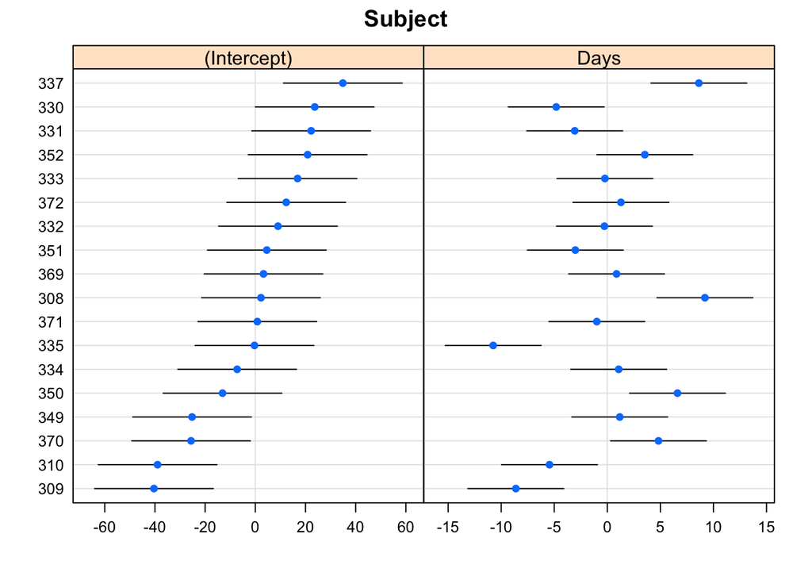

```r
# From the help on ranef
str(ranef(sleep_mod))
as.data.frame(ranef(sleep_mod))
rr <- ranef(sleep_mod)
dd <- as.data.frame(rr)
dotplot(rr,scales = list(x = list(relation = 'free')))[["Subject"]] # This just allows the x access to be different between the two objects
```

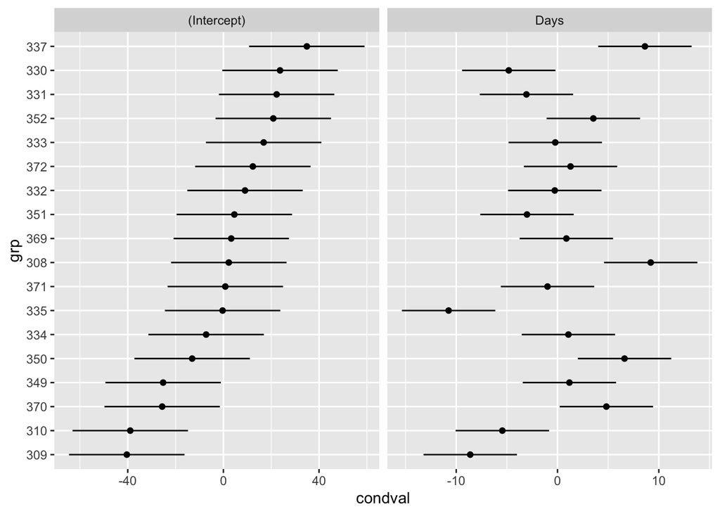

```r
# How to replicate dotplot in ggplot!
# The "free_x" is allowing different value scales...
ggplot(dd, aes(y=grp,x=condval)) +
  geom_point() + facet_wrap(~term,scales="free_x") +
  geom_errorbarh(aes(xmin=condval -2*condsd,
                     xmax=condval +2*condsd), height=0)
```

### Random Effect Variance

More specifically, these are the variances of the conditional modes

```r
cov_mat <- VarCorr(sleep_mod)[["Subject"]]
cov_mat # shows the correlation between random effects as well
```

```
##             (Intercept)      Days
## (Intercept)  612.100158  9.604409
## Days           9.604409 35.071714
## attr(,"stddev")
## (Intercept)        Days
##   24.740658    5.922138
## attr(,"correlation")
##             (Intercept)       Days
## (Intercept)  1.00000000 0.06555124
## Days         0.06555124 1.00000000
```

```r
print(VarCorr(sleep_mod), comp=c("Variance")) # extract the variance estimates of random effects (shown in summary)
```

```
##  Groups   Name        Variance Corr
##  Subject  (Intercept) 612.100
##           Days         35.072  0.066
##  Residual             654.940
```

```r
attr(ranef(sleep_mod)$Subject, "postVar")
```

```
## , , 1
##
##          [,1]       [,2]
## [1,] 145.7056 -21.444504
## [2,] -21.4445   5.312283
##
## , , 2
##
##          [,1]       [,2]
## [1,] 145.7056 -21.444504
## [2,] -21.4445   5.312283
##
## , , 3
##
##          [,1]       [,2]
## [1,] 145.7056 -21.444504
## [2,] -21.4445   5.312283
##
## , , 4
##
##          [,1]       [,2]
## [1,] 145.7056 -21.444504
## [2,] -21.4445   5.312283
##
## , , 5
##
##          [,1]       [,2]
## [1,] 145.7056 -21.444504
## [2,] -21.4445   5.312283
##
## , , 6
##
##          [,1]       [,2]
## [1,] 145.7056 -21.444504
## [2,] -21.4445   5.312283
##
## , , 7
##
##          [,1]       [,2]
## [1,] 145.7056 -21.444504
```

[output cut: 52 more lines]

```
##          [,1]       [,2]
## [1,] 145.7056 -21.444504
## [2,] -21.4445   5.312283
##
## , , 17
##
##          [,1]       [,2]
## [1,] 145.7056 -21.444504
## [2,] -21.4445   5.312283
##
## , , 18
##
##          [,1]       [,2]
## [1,] 145.7056 -21.444504
## [2,] -21.4445   5.312283
```

```r
# ?ranef
```

A cleaner data frame version of the above with standard deviations, (no correlation)

```r
as.data.frame(ranef(sleep_mod))
```

```
##     grpvar        term grp     condval    condsd
## 1  Subject (Intercept) 308   2.2585509 12.070857
## 2  Subject (Intercept) 309 -40.3987381 12.070857
## 3  Subject (Intercept) 310 -38.9604090 12.070857
## 4  Subject (Intercept) 330  23.6906196 12.070857
## 5  Subject (Intercept) 331  22.2603126 12.070857
## 6  Subject (Intercept) 332   9.0395679 12.070857
## 7  Subject (Intercept) 333  16.8405086 12.070857
## 8  Subject (Intercept) 334  -7.2326151 12.070857
## 9  Subject (Intercept) 335  -0.3336684 12.070857
## 10 Subject (Intercept) 337  34.8904868 12.070857
## 11 Subject (Intercept) 349 -25.2102286 12.070857
## 12 Subject (Intercept) 350 -13.0700342 12.070857
## 13 Subject (Intercept) 351   4.5778642 12.070857
## 14 Subject (Intercept) 352  20.8636782 12.070857
```

[output cut: 22 more lines]

```r
# broom.mixed alternative, with same output
broom.mixed::tidy(sleep_mod, effects = "ran_vals")
```

```
## # A tibble: 36 × 6
##    effect   group   level term        estimate std.error
##    <chr>    <chr>   <chr> <chr>          <dbl>     <dbl>
##  1 ran_vals Subject 308   (Intercept)    2.26       12.1
##  2 ran_vals Subject 309   (Intercept)  -40.4        12.1
##  3 ran_vals Subject 310   (Intercept)  -39.0        12.1
##  4 ran_vals Subject 330   (Intercept)   23.7        12.1
##  5 ran_vals Subject 331   (Intercept)   22.3        12.1
##  6 ran_vals Subject 332   (Intercept)    9.04       12.1
##  7 ran_vals Subject 333   (Intercept)   16.8        12.1
##  8 ran_vals Subject 334   (Intercept)   -7.23       12.1
##  9 ran_vals Subject 335   (Intercept)   -0.334      12.1
## 10 ran_vals Subject 337   (Intercept)   34.9        12.1
## # … with 26 more rows
## # ℹ Use `print(n = ...)` to see more rows
```

## Plotting Effects

There are a few packages that automate the effect plotting

- “effects”
- “ggeffects”
- [“sjPlot”](https://cran.r-project.org/web/packages/sjPlot/vignettes/plot_model_estimates.html)

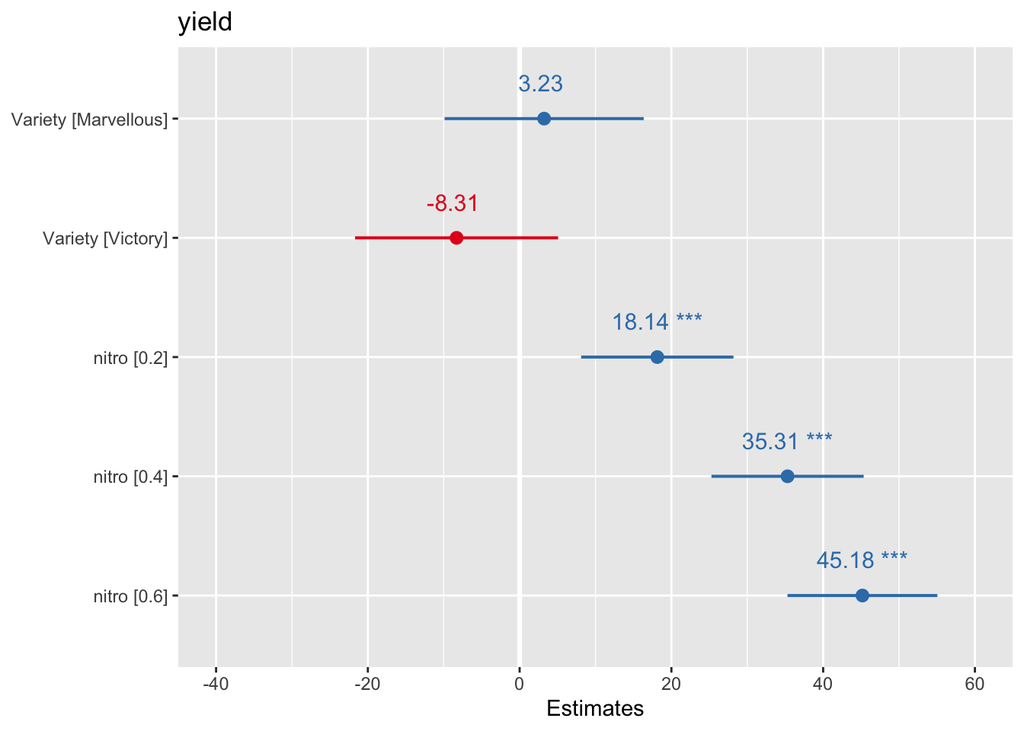

```r
# sjPLot
plot_model(oats_mod,
           show.values = TRUE,  # show overlay
           value.offset = .3) # offset above
```

some useful options

- `terms = c("factor(nitro)0.2", "factor(nitro)0.4"`

# Inference in Mixed Models

A wonderful resource for discussing inference in mixed models is given by [Faraway’s Inferential Methods for Linear Mixed Models](https://people.bath.ac.uk/jjf23/mixchange/index.html#worked-examples)

# Computational Notes

- For large models, with crossed and partially crossed factors, you should consider adding `gradient = FALSE, niterEM = 0)`, because the gradient calculation and EMCE iteration both require a calculation that needs to invert a cholesky factor of crossproduct matrix. It’s a slow process and can slow down the optimization. Bates said maybe it could be default when there are multiple, non-nested grouping factors. See [thread](https://stat.ethz.ch/pipermail/r-help/2006-October/115572.html) for more details.

# Cookbook

## Plot of Shrinkage (sleepstudy)

This stuff is from this blog post: https://www.tjmahr.com/plotting-partial-pooling-in-mixed-effects-models/

Looking at the shrinkage stuff though, there’s also from [Bates](http://lme4.r-forge.r-project.org/slides/2011-03-16-Amsterdam/2Longitudinal.pdf)

```r
sleepstudy <- sleepstudy %>% as_tibble() %>% mutate(Subject = as.character(Subject))
sleepstudy
```

```
## # A tibble: 180 × 3
##    Reaction  Days Subject
##       <dbl> <dbl> <chr>
##  1     250.     0 308
##  2     259.     1 308
##  3     251.     2 308
##  4     321.     3 308
##  5     357.     4 308
##  6     415.     5 308
##  7     382.     6 308
##  8     290.     7 308
##  9     431.     8 308
## 10     466.     9 308
## # … with 170 more rows
## # ℹ Use `print(n = ...)` to see more rows
```

```r
# Adding two participants to illustrate partial pooling
df_sleep <- bind_rows(
  sleepstudy,
  tibble(Reaction = c(286, 288), Days = 0:1, Subject = "374"),
  tibble(Reaction = 245, Days = 0, Subject = "373"))
```

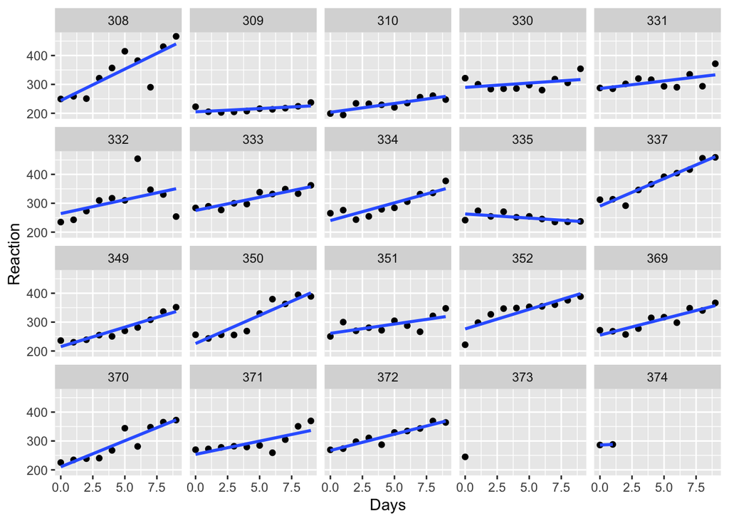

```r
ggplot(df_sleep, aes(Days, Reaction)) +
  facet_wrap(~Subject) +
  geom_point() +
  geom_smooth(method=lm, se=FALSE)
```

Fitting all the linear models all at once, `lme4` provides a convenience function for that with s3 methods defined as well: coef, confint, fitted, fixef, formula, logLik, pairs, plot, predict, print, qqnorm, ranef, residuals, sigma, summary, and update

### No Pooling

```r
# Creating the no pooling model
# This is basically an ANCOVA lm(Reaction ~ Days + Subject)

df_no_pooling <- lmList(Reaction ~ Days | Subject, data=df_sleep) %>%
  coef() %>%
  rownames_to_column("Subject") %>%
  rename(Intercept = `(Intercept)`, Slope_Days = Days) %>%
  add_column(Model = "No Pooling") %>%
  filter(Subject != "373")
# ?lmList # Creates a linear model for each one.
```

### Pooled

```r
# Creating pooled model
m_pooled <- lm(Reaction ~ Days, df_sleep)
df_pooled <- tibble(
  Model = "Complete pooling",
  Subject = unique(df_sleep$Subject),
  Intercept = coef(m_pooled)[1],
  Slope_Days = coef(m_pooled)[2])
```

```r
# combine the two models
df_models <- bind_rows(df_pooled, df_no_pooling) %>%
  left_join(df_sleep, by = "Subject")
df_models
```

```
## # A tibble: 365 × 6
##    Model            Subject Intercept Slope_Days Reaction  Days
##    <chr>            <chr>       <dbl>      <dbl>    <dbl> <dbl>
##  1 Complete pooling 308          252.       10.3     250.     0
##  2 Complete pooling 308          252.       10.3     259.     1
##  3 Complete pooling 308          252.       10.3     251.     2
##  4 Complete pooling 308          252.       10.3     321.     3
##  5 Complete pooling 308          252.       10.3     357.     4
##  6 Complete pooling 308          252.       10.3     415.     5
##  7 Complete pooling 308          252.       10.3     382.     6
##  8 Complete pooling 308          252.       10.3     290.     7
##  9 Complete pooling 308          252.       10.3     431.     8
## 10 Complete pooling 308          252.       10.3     466.     9
## # … with 355 more rows
## # ℹ Use `print(n = ...)` to see more rows
```

### Partial Pooling

```r
lmm <- lmer(Reaction ~ 1 + Days + (1 + Days | Subject), df_sleep)

# Make a dataframe with the fitted effects
df_partial_pooling <- coef(lmm)[["Subject"]] %>%
  rownames_to_column("Subject") %>%
  as_tibble() %>%
  rename(Intercept = `(Intercept)`, Slope_Days = Days) %>%
  add_column(Model = "Partial pooling")

df_models <- bind_rows(df_pooled, df_no_pooling, df_partial_pooling) %>%
  left_join(df_sleep, by = "Subject")
```

### Plot comparing all versions

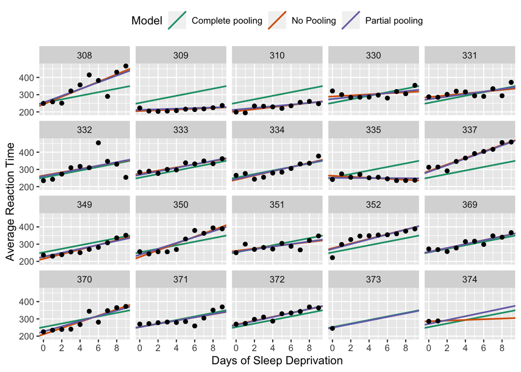

```r
# Create initial base plot without partial pooling lines
p_model_comparison <- ggplot(df_models) +
  aes(x = Days, y = Reaction) +
  # Set the color mapping in this layer so the points don't get a color
  geom_abline(aes(intercept = Intercept, slope = Slope_Days, color = Model),
              size = .75) +
  geom_point() +
  facet_wrap(~Subject) +
  scale_x_continuous(breaks = 0:4 * 2) +
  labs(x = "Days of Sleep Deprivation", y = "Average Reaction Time") +
  scale_color_brewer(palette = "Dark2") +
  theme(legend.position = "top")
# p_model_comparison # to view without partial pooling

p_model_comparison
```

### Linear Model Version Estimates

```r
m <- lm(formula = Reaction ~ Days*Subject, data = df_sleep)
coef(m)
```

```
##     (Intercept)            Days      Subject309      Subject310      Subject330
##     244.1926691      21.7647024     -39.1377236     -40.7084436      45.4924236
##      Subject331      Subject332      Subject333      Subject334      Subject335
##      41.5462964      20.0589455      30.8264364      -4.0297545      18.8420236
##      Subject337      Subject349      Subject350      Subject351      Subject352
##      45.9114582     -29.0808964     -18.3580655      16.9543418      32.1794000
##      Subject369      Subject370      Subject371      Subject372      Subject373
##      10.7754800     -33.7435782       9.4433691      22.8521309       0.8073309
##      Subject374 Days:Subject309 Days:Subject310 Days:Subject330 Days:Subject331
##      41.8073309     -19.5029170     -15.6498036     -18.7566297     -16.4986836
## Days:Subject332 Days:Subject333 Days:Subject334 Days:Subject335 Days:Subject337
##     -12.1979345     -12.6226570      -9.5115612     -24.6457364      -2.7387285
## Days:Subject349 Days:Subject350 Days:Subject351 Days:Subject352 Days:Subject369
##      -8.2707697      -2.2606855     -15.3312048      -8.1981533     -10.4165933
## Days:Subject370 Days:Subject371 Days:Subject372 Days:Subject373 Days:Subject374
##      -3.7085515     -12.5762576     -10.4666291              NA     -19.7647024
```

```r
# In this information, there is really a line for each subject, need to create that matrix

mcoef <- tibble(Subject = "308", Intercept = coef(m)[1], Slope_Days = coef(m)[2])
mcoef <- rbind(mcoef,
               tibble(
                 Subject = substr(names(coef(m)[3:21]), 8,10),
                 Intercept = coef(m)[3:21] + coef(m)[1],
                 Slope_Days = coef(m)[22:40] + coef(m)[2]))
mcoef$Model <- "Linear Model"
df_ancova <- mcoef

df_models <- bind_rows(df_pooled, df_no_pooling, df_partial_pooling, df_ancova) %>%
  left_join(df_sleep, by = "Subject")

# Oh it's the same as no pooling
df_models %>% filter((Model == "Linear Model" | Model == "No Pooling") & Subject == "370" & Days == 0)
```

```
## # A tibble: 2 × 6
##   Model        Subject Intercept Slope_Days Reaction  Days
##   <chr>        <chr>       <dbl>      <dbl>    <dbl> <dbl>
## 1 No Pooling   370          210.       18.1     225.     0
## 2 Linear Model 370          210.       18.1     225.     0
```

Effectively, this is the same as filtering the data and running a linear regression on each subset. That is what is meant by “no pooling”

```r
mf <- lm(Reaction ~ Days, subset(df_sleep, Subject == "308"))
coef(mf)
```

```
## (Intercept)        Days
##    244.1927     21.7647
```

```r
coef(m)[1:2]
```

```
## (Intercept)        Days
##    244.1927     21.7647
```

```r
fixef(lmm)
```

```
## (Intercept)        Days
##   252.54256    10.45212
```

```r
coef(lmm)
```

```
## $Subject
##     (Intercept)       Days
## 308    253.9478 19.6264337
## 309    211.7331  1.7319161
## 310    213.1582  4.9061511
## 330    275.1425  5.6436007
## 331    273.7286  7.3862730
## 332    260.6504 10.1632571
## 333    268.3683 10.2246059
## 334    244.5524 11.4837802
## 335    251.3702 -0.3355788
## 337    286.2319 19.1090424
## 349    226.7663 11.5531844
## 350    238.7807 17.0156827
## 351    256.2344  7.4119456
## 352    272.3511 13.9920878
## 369    254.9484 11.2985770
## 370    226.3701 15.2027877
## 371    252.5051  9.4335409
## 372    263.8916 11.7253429
## 373    248.9753 10.3915288
## 374    271.1450 11.0782516
##
## attr(,"class")
## [1] "coef.mer"
```

The standard errors is where it matters… let’s look at that… say I’m interested in saying something about the subject 308. How would I go about that? The answer is that it’s difficult without making some egregarious assumptions.

https://stackoverflow.com/questions/26198958/extracting-coefficients-and-their-standard-error-from-lme

```r
# filtered model for patient 308
coef(summary(mf))
```

```
##             Estimate Std. Error  t value     Pr(>|t|)
## (Intercept) 244.1927   28.08269 8.695486 2.385022e-05
## Days         21.7647    5.26037 4.137485 3.264657e-03
```

```r
# Coef of blocked model
coef(summary(m))
```

```
##                    Estimate Std. Error     t value     Pr(>|t|)
## (Intercept)     244.1926691  15.041687 16.23439348 2.419368e-34
## Days             21.7647024   2.817566  7.72464642 1.741840e-12
## Subject309      -39.1377236  21.272158 -1.83985675 6.784831e-02
## Subject310      -40.7084436  21.272158 -1.91369599 5.764319e-02
## Subject330       45.4924236  21.272158  2.13858996 3.415609e-02
## Subject331       41.5462964  21.272158  1.95308328 5.274863e-02
## Subject332       20.0589455  21.272158  0.94296711 3.472771e-01
## Subject333       30.8264364  21.272158  1.44914476 1.494714e-01
## Subject334       -4.0297545  21.272158 -0.18943797 8.500163e-01
## Subject335       18.8420236  21.272158  0.88575985 3.772237e-01
## Subject337       45.9114582  21.272158  2.15828869 3.256308e-02
## Subject349      -29.0808964  21.272158 -1.36708726 1.737283e-01
## Subject350      -18.3580655  21.272158 -0.86300907 3.895675e-01
## Subject351       16.9543418  21.272158  0.79702030 4.267514e-01
## Subject352       32.1794000  21.272158  1.51274731 1.325355e-01
## Subject369       10.7754800  21.272158  0.50655321 6.132431e-01
## Subject370      -33.7435782  21.272158 -1.58627902 1.148695e-01
## Subject371        9.4433691  21.272158  0.44393094 6.577589e-01
## Subject372       22.8521309  21.272158  1.07427421 2.844966e-01
## Subject373        0.8073309  29.684902  0.02719668 9.783405e-01
## Subject374       41.8073309  29.684902  1.40837020 1.611769e-01
## Days:Subject309 -19.5029170   3.984640 -4.89452386 2.609126e-06
## Days:Subject310 -15.6498036   3.984640 -3.92753235 1.326622e-04
## Days:Subject330 -18.7566297   3.984640 -4.70723286 5.841112e-06
## Days:Subject331 -16.4986836   3.984640 -4.14057040 5.875009e-05
## Days:Subject332 -12.1979345   3.984640 -3.06123857 2.630447e-03
## Days:Subject333 -12.6226570   3.984640 -3.16782847 1.875589e-03
## Days:Subject334  -9.5115612   3.984640 -2.38705643 1.828240e-02
## Days:Subject335 -24.6457364   3.984640 -6.18518475 6.072281e-09
## Days:Subject337  -2.7387285   3.984640 -0.68732139 4.929857e-01
## Days:Subject349  -8.2707697   3.984640 -2.07566282 3.970366e-02
## Days:Subject350  -2.2606855   3.984640 -0.56734995 5.713599e-01
## Days:Subject351 -15.3312048   3.984640 -3.84757562 1.786891e-04
## Days:Subject352  -8.1981533   3.984640 -2.05743875 4.144801e-02
## Days:Subject369 -10.4165933   3.984640 -2.61418662 9.894962e-03
## Days:Subject370  -3.7085515   3.984640 -0.93071174 3.535604e-01
## Days:Subject371 -12.5762576   3.984640 -3.15618391 1.946990e-03
## Days:Subject372 -10.4666291   3.984640 -2.62674378 9.553514e-03
## Days:Subject374 -19.7647024  36.301801 -0.54445515 5.869704e-01
```

```r
# CAUTION: Ignoring Covariances, and directly adding the variances for Conditional Variance and fixed eff variance
sqrt(diag(vcov(lmm)) + diag(attr(ranef(lmm)$Subject, "postVar")[,,1]))
```

```
## (Intercept)        Days
##   13.575606    2.758914
```

```r
df_fixef <- tibble(
  Model = "Partial pooling (average)",
  Intercept = fixef(lmm)[1],
  Slope_Days = fixef(lmm)[2])

# Complete pooling / fixed effects are center of gravity in the plot
df_gravity <- df_pooled %>%
  distinct(Model, Intercept, Slope_Days) %>%
  bind_rows(df_fixef)
df_gravity
```

```
## # A tibble: 2 × 3
##   Model                     Intercept Slope_Days
##   <chr>                         <dbl>      <dbl>
## 1 Complete pooling               252.       10.3
## 2 Partial pooling (average)      253.       10.5
```

```r
df_pulled <-  bind_rows(df_no_pooling, df_partial_pooling)
head(df_pulled)
```

```
##   Subject Intercept Slope_Days      Model
## 1     308  244.1927  21.764702 No Pooling
## 2     309  205.0549   2.261785 No Pooling
## 3     310  203.4842   6.114899 No Pooling
## 4     330  289.6851   3.008073 No Pooling
## 5     331  285.7390   5.266019 No Pooling
## 6     332  264.2516   9.566768 No Pooling
```

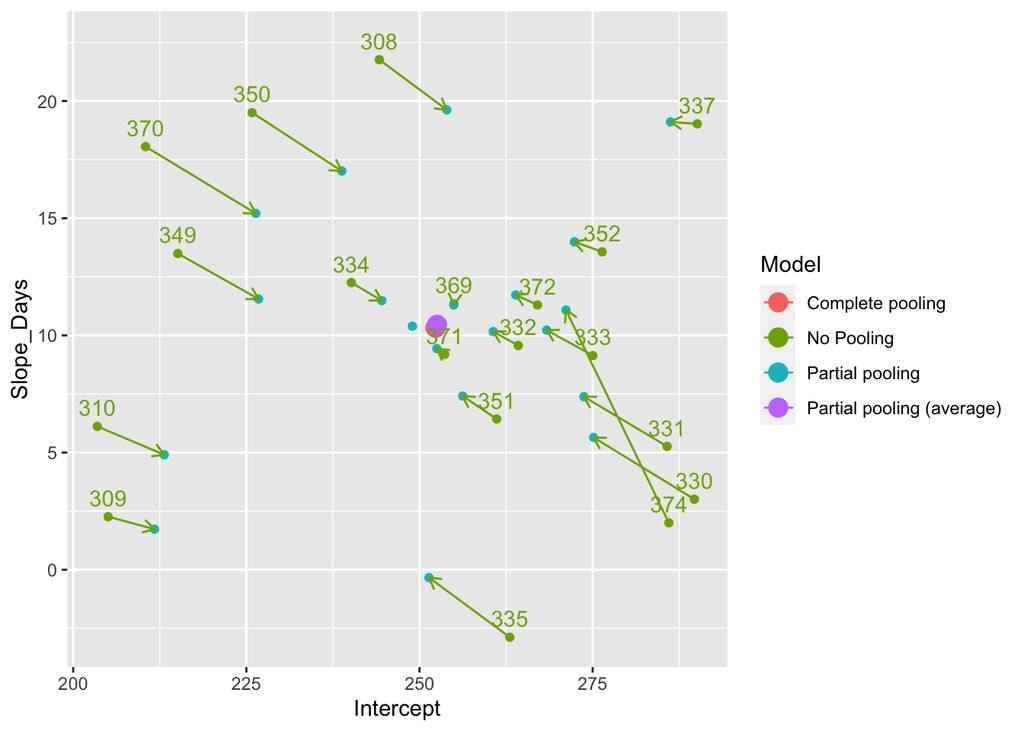

```r
ggplot(df_pulled, aes(Intercept, Slope_Days, color=Model)) +
  geom_point() +
  geom_point(data=df_gravity, size=4) +
  geom_path(aes(group=Subject), arrow=arrow(length=unit(.02, "npc"))) +
  geom_text(aes(label=Subject), data=df_no_pooling, nudge_y = .8)
```

## Getting Subject level standard errors

Complicated Issue, according to [Ben Bolker](https://stackoverflow.com/questions/26198958/extracting-coefficients-and-their-standard-error-from-lme)

```r
fixed_vars <- diag(vcov(mod))
attributes(ranef(mod, condVar=TRUE, drop=TRUE)$Subject)

attributes(ranef(mod)$Subject)
attr(ranef(mod)$Subject, "postVar")
cmode_vars <- t(apply(attr(ranef(mod)$Subject, "postVar"), 3, diag)) # columns of intercept variance and day variance

sqrt(sweep(cmode_vars, 2, fixed_vars, "+")) # Standard errors  (basically add fixed_vars to respective columns)
```

## Emmeans with Mixed Models (oats)

```r
oats_emm <- emmeans(oats_mod, c("Variety", "nitro"), lmer.df = "satterthwaite") # Also affects the SE slightly
oats_emm
```

```
##  Variety     nitro emmean   SE    df lower.CL upper.CL
##  Golden Rain   0.0   80.6 8.18 10.54     62.5     98.7
##  Marvellous    0.0   83.8 8.15 10.40     65.8    101.9
##  Victory       0.0   72.3 8.34 11.26     54.0     90.6
##  Golden Rain   0.2   98.7 8.02  9.76     80.8    116.6
##  Marvellous    0.2  102.0 8.08 10.07     84.0    119.9
##  Victory       0.2   90.4 8.17 10.39     72.3    108.5
##  Golden Rain   0.4  115.9 8.09 10.14     97.9    133.9
##  Marvellous    0.4  119.1 8.00  9.69    101.2    137.0
##  Victory       0.4  107.6 8.17 10.39     89.5    125.7
##  Golden Rain   0.6  125.8 8.09 10.07    107.8    143.8
##  Marvellous    0.6  129.0 7.99  9.61    111.1    146.9
##  Victory       0.6  117.5 8.03  9.79     99.5    135.4
##
## Degrees-of-freedom method: satterthwaite
## Confidence level used: 0.95
```

### Manual calculation of emmeans and SE

Emmeans simply takes advantage of the fact that the marginal means are the linear combinations of the coefficients. Thus, if the model coefficient standard deviations are incorrect, then the estimated marginal means standard errrors are incorrect.

To replicate the standard errors within emmeans, you must use REML estimates of standards errors.

Overall, we can create the reference grid manually and calculate the marginal means from the grid

```r
# calculate reference grid manually
oats_grid <- with(oats_miss, expand.grid(Variety = levels(Variety),
                                         nitro = levels(factor(nitro))))
oats_X <- model.matrix(~Variety + nitro, data = oats_grid) # the combinations
oats_B <- fixef(oats_mod)
oats_V <- vcov(oats_mod)

# Calculate my version
oats_my_emm <- list(emmean = c(oats_X %*% oats_B), # marginal means are just X\betahat
                    SE = sqrt(diag(oats_X %*% oats_V %*% t(oats_X)))) # cov(X\beta) = Xcov(\betahat)X'

# Calculate the package version
oats_package_emm <- oats_emm %>% as_tibble() %>% dplyr::select(emmean, SE) %>% as.list()


# Show that emmean estimates are the same
cbind(oats_my_emm$emmean, oats_package_emm$emmean)
```

```
##            [,1]      [,2]
##  [1,]  80.58462  80.58462
##  [2,]  83.81332  83.81332
##  [3,]  72.27827  72.27827
##  [4,]  98.72680  98.72680
##  [5,] 101.95550 101.95550
##  [6,]  90.42045  90.42045
##  [7,] 115.89071 115.89071
##  [8,] 119.11941 119.11941
##  [9,] 107.58436 107.58436
## [10,] 125.76112 125.76112
## [11,] 128.98982 128.98982
## [12,] 117.45477 117.45477
```

```r
# Show that SE calculations are the same (note, they're only the same when you use Satter)
cbind(oats_my_emm$SE, oats_package_emm$SE)
```

```
##        [,1]     [,2]
## 1  8.180084 8.180084
## 2  8.145113 8.145113
## 3  8.342494 8.342494
## 4  8.015913 8.015913
## 5  8.078163 8.078163
## 6  8.171648 8.171648
## 7  8.093027 8.093027
## 8  8.001749 8.001749
## 9  8.171293 8.171293
## 10 8.087191 8.087191
## 11 7.985790 7.985790
## 12 8.030997 8.030997
```

Note:

- SE are the same when you calculate them with `REML = TRUE` and `lmer.df = "satterthwaite"`.

In order to average these down (by Variety) we then just get the appropriate linear combinations and calculate them with the appropriate variance-covariance.

# Additional Resources

# FAQ

- Why aren’t there p-values in lme4?
  - Great question. it’s due to the denominator degrees of freedom. really
  - Bates response is at `?pvalues`
- What’s the difference between nlme and lme4
  - [gn]lmer now produces objects of class merMod rather than class mer as before
  - the new version uses a combination of S3 and reference classes (see ReferenceClasses, merPredD-class, and lmResp-class) as well as S4 classes; partly for this reason it is more interoperable with nlme
  - The internal structure of [gn]lmer is now more modular, allowing finer control of the different steps of argument checking; construction of design matrices and data structures; parameter estimation; and construction of the final merMod object (see modular)
  - profiling and parametric bootstrapping are new in the current version
  - the new version of lme4 does not provide an mcmcsamp (post-hoc MCMC sampling) method, because this was deemed to be unreliable. Alternatives for computing p-values include parametric bootstrapping (bootMer) or methods implemented in the pbkrtest package and leveraged by the lmerTest package and the Anova function in the car package (see pvalues for more details).